# Telco

Tiana Cofer

2025-02-06

```r
#Clear environment(optional)
rm(list = ls())
```

```r
library(readr)
library(tidyverse)
library(dplyr)
library(psych)
```

```r
telco <- read.csv('/Users/anais/Library/CloudStorage/OneDrive-Personal/Data Science/Telco-Customer-Churn.csv')
```

Research Question: Which customer segments have the highest churn risk?

Additional Questions 1. Which subscription plans are most associated with customer churn? 2. What customer behaviors serve as strong predictors of churn? 3. Can we build a predictive model for churn?

*Dictionary* customerID - ID number of customer gender - if customer is male/female SeniorCitizen - if customer is senior citizen Partner - if customer has a partner Dependents - if customer has dependents tenure - # of months customer has used the service PhoneService - if customer has phone service MultipleLines - if customer has multiple lines (yes=they have multiple lines, no=they don’t have multiple lines, no phone service=might have multiple lines but no phone service, or might not have multiple lines and have no phone service) InternetService - if customer has internet service OnlineSecurity - if they have online security OnlineBackup - if they have online backup DeviceProtection - if they have device protection TechSupport - if customer has tech support StreamingTV - if customer has tv streaming StreamingMovies - if customer has movie streaming Contract - contract term of the customer (month-to-month, 1 yr, 2 yr) PaperlessBilling - if they have paperless billing PaymentMethod - customer’s payment method MonthlyCharges - amount charged to customer monthly TotalCharges - total amount charged to customer Churn - whether the customer churned or not

```r
summary(telco)
```

```
##   customerID           gender          SeniorCitizen      Partner
##  Length:7043        Length:7043        Min.   :0.0000   Length:7043
##  Class :character   Class :character   1st Qu.:0.0000   Class :character
##  Mode  :character   Mode  :character   Median :0.0000   Mode  :character
##                                        Mean   :0.1621
##                                        3rd Qu.:0.0000
##                                        Max.   :1.0000
##
##   Dependents            tenure      PhoneService       MultipleLines
##  Length:7043        Min.   : 0.00   Length:7043        Length:7043
##  Class :character   1st Qu.: 9.00   Class :character   Class :character
##  Mode  :character   Median :29.00   Mode  :character   Mode  :character
##                     Mean   :32.37
##                     3rd Qu.:55.00
##                     Max.   :72.00
##
##  InternetService    OnlineSecurity     OnlineBackup       DeviceProtection
##  Length:7043        Length:7043        Length:7043        Length:7043
##  Class :character   Class :character   Class :character   Class :character
##  Mode  :character   Mode  :character   Mode  :character   Mode  :character
##
##
##
##
##  TechSupport        StreamingTV        StreamingMovies      Contract
##  Length:7043        Length:7043        Length:7043        Length:7043
##  Class :character   Class :character   Class :character   Class :character
##  Mode  :character   Mode  :character   Mode  :character   Mode  :character
##
##
##
##
##  PaperlessBilling   PaymentMethod      MonthlyCharges    TotalCharges
##  Length:7043        Length:7043        Min.   : 18.25   Min.   :  18.8
##  Class :character   Class :character   1st Qu.: 35.50   1st Qu.: 401.4
##  Mode  :character   Mode  :character   Median : 70.35   Median :1397.5
##                                        Mean   : 64.76   Mean   :2283.3
##                                        3rd Qu.: 89.85   3rd Qu.:3794.7
##                                        Max.   :118.75   Max.   :8684.8
##                                                         NA's   :11
##     Churn
##  Length:7043
##  Class :character
##  Mode  :character
##
##
##
##
```

Drop all the “no internet service” appearances in the dataset

```r
telco[telco == "No internet service"] <- NA
```

Convert non-numeric data to binary

```r
#Key services

#Phone service
telco$PSbin <- NA
telco$PSbin[telco$PhoneService == "Yes"] <- 1
telco$PSbin[telco$PhoneService == "No"] <- 0

#Internet Service
telco$ISbin <- ifelse(telco$InternetService == "No", 0, 1)

#TV streaming
telco$STbin <- NA
telco$STbin[telco$StreamingTV == "Yes"] <- 1
telco$STbin[telco$StreamingTV == "No"] <- 0

#Movie streaming
telco$SMbin <- NA
telco$SMbin[telco$StreamingMovies == "Yes"] <- 1
telco$SMbin[telco$StreamingMovies == "No"] <- 0

#Online security
telco$OSbin <- NA
telco$OSbin[telco$OnlineSecurity == "Yes"] <- 1
telco$OSbin[telco$OnlineSecurity == "No"] <- 0

#Online backup
telco$OBbin <- NA
telco$OBbin[telco$OnlineBackup == "Yes"] <- 1
telco$OBbin[telco$OnlineBackup == "No"] <- 0

#Device protection
telco$DPbin <- NA
telco$DPbin[telco$DeviceProtection == "Yes"] <- 1
telco$DPbin[telco$DeviceProtection == "No"] <- 0
```

Other variables to control for

```r
#Key variable (churn)
telco$Chbin <- NA
telco$Chbin[telco$Churn == "Yes"] <- 1
telco$Chbin[telco$Churn == "No"] <- 0

#Many lines
telco$MLbin <- NA
telco$MLbin[telco$MultipleLines == "Yes"] <- 1
telco$MLbin[telco$MultipleLines == "No"] <- 0
telco$MLbin[telco$MultipleLines == "No phone service"] <- NA

#Tech support
telco$TSbin <- NA
telco$TSbin[telco$TechSupport == "Yes"] <- 1
telco$TSbin[telco$TechSupport == "No"] <- 0

#Gender, male/female
telco$Gbin <- NA
telco$Gbin[telco$gender == "Male"] <- 1
telco$Gbin[telco$gender == "Female"] <- 0

#Contract length
telco$Cbin <- NA
telco$Cbin[telco$Contract == "Month-to-month"] <- 2
telco$Cbin[telco$Contract == "One year"] <- 1
telco$Cbin[telco$Contract == "Two year"] <- 0

#Paperless billing
telco$PBbin <- NA
telco$PBbin[telco$PaperlessBilling == "Yes"] <- 1
telco$PBbin[telco$PaperlessBilling == "No"] <- 0

#Payment methods
telco$Paybin <- NA
telco$Paybin[telco$PaymentMethod == "Electronic Check"] <- 2
telco$Paybin[telco$PaymentMethod == "Mailed Check"] <- 1
telco$Paybin[telco$PaymentMethod == "Bank transfer (automatic)"] <- 0
```

Which subscription plans are most associated with customer churn? There are 7 types of service: phone, tv, movies, internet, and 3 device protections

```r
#Compare variables with each to see significance
#Make tables of variables to compare

#Phone service, churn
PCHtab <- table(telco$PSbin, telco$Chbin)
#Internet service, churn
IStab <- table(telco$ISbin, telco$Chbin)
#TV streaming, churn
STtab <- table(telco$STbin, telco$Chbin)
#Movie streaming, churn
SMtab <- table(telco$SMbin, telco$Chbin)
#Online security
OStab <- table(telco$OnlineSecurity, telco$Chbin)
#Online backup
OBtab <- table(telco$OnlineBackup, telco$Chbin)
#Device protection
DPtab <- table(telco$DeviceProtection, telco$Chbin)
```

```r
#Run correlation with psych library
phi(PCHtab, 3)
```

```
## [1] 0.012
```

```r
phi(IStab, 3)
```

```
## [1] 0.228
```

```r
phi(STtab, 3)
```

```
## [1] -0.037
```

```r
phi(SMtab, 3)
```

```
## [1] -0.04
```

```r
phi(OStab, 3)
```

```
## [1] -0.281
```

```r
phi(OBtab, 3)
```

```
## [1] -0.196
```

```r
phi(DPtab, 3)
```

```
## [1] -0.177
```

It appears that phone service with churn and internet service with churn have positive correlations. Streaming movies and streaming tv with churn has a negative correlation.

## Now that correlations have been run, regression models can be run to find significance.

```r
#Phone service, churn
m1 <- lm(telco$Chbin ~ telco$PSbin)
summary(m1)
```

```
##
## Call:
## lm(formula = telco$Chbin ~ telco$PSbin)
##
## Residuals:
##     Min      1Q  Median      3Q     Max
## -0.2671 -0.2671 -0.2671  0.7329  0.7507
##
## Coefficients:
##             Estimate Std. Error t value Pr(>|t|)
## (Intercept)  0.24927    0.01691  14.742   <2e-16 ***
## telco$PSbin  0.01783    0.01779   1.002    0.316
## ---
## Signif. codes:  0 '***' 0.001 '**' 0.01 '*' 0.05 '.' 0.1 ' ' 1
##
## Residual standard error: 0.4416 on 7041 degrees of freedom
## Multiple R-squared:  0.0001426,  Adjusted R-squared:  6.059e-07
## F-statistic: 1.004 on 1 and 7041 DF,  p-value: 0.3163
```

It appears that phone service doesn’t have much of an effect on churn rate

```r
#Internet service, churn
m2 <- lm(telco$Chbin ~ telco$ISbin)
summary(m2)
```

```
##
## Call:
## lm(formula = telco$Chbin ~ telco$ISbin)
##
## Residuals:
##     Min      1Q  Median      3Q     Max
## -0.3183 -0.3183 -0.3183  0.6817  0.9260
##
## Coefficients:
##             Estimate Std. Error t value Pr(>|t|)
## (Intercept)  0.07405    0.01101   6.728 1.86e-11 ***
## telco$ISbin  0.24424    0.01244  19.639  < 2e-16 ***
## ---
## Signif. codes:  0 '***' 0.001 '**' 0.01 '*' 0.05 '.' 0.1 ' ' 1
##
## Residual standard error: 0.43 on 7041 degrees of freedom
## Multiple R-squared:  0.05193,    Adjusted R-squared:  0.0518
## F-statistic: 385.7 on 1 and 7041 DF,  p-value: < 2.2e-16
```

Internet service has a positive correlation with churn. It’s also significant because of the three stars and the p-value being less than 0.05.

```r
#TV streaming, churn
m3 <- lm(telco$Chbin ~ telco$STbin)
summary(m3)
```

```
##
## Call:
## lm(formula = telco$Chbin ~ telco$STbin)
##
## Residuals:
##     Min      1Q  Median      3Q     Max
## -0.3352 -0.3352 -0.3007  0.6648  0.6993
##
## Coefficients:
##              Estimate Std. Error t value Pr(>|t|)
## (Intercept)  0.335231   0.008783  38.169  < 2e-16 ***
## telco$STbin -0.034529   0.012538  -2.754  0.00591 **
## ---
## Signif. codes:  0 '***' 0.001 '**' 0.01 '*' 0.05 '.' 0.1 ' ' 1
##
## Residual standard error: 0.4656 on 5515 degrees of freedom
##   (1526 observations deleted due to missingness)
## Multiple R-squared:  0.001373,   Adjusted R-squared:  0.001192
## F-statistic: 7.584 on 1 and 5515 DF,  p-value: 0.005909
```

```r
#Movie streaming, churn
m4 <- lm(telco$Chbin ~ telco$SMbin)
summary(m4)
```

```
##
## Call:
## lm(formula = telco$Chbin ~ telco$SMbin)
##
## Residuals:
##     Min      1Q  Median      3Q     Max
## -0.3368 -0.3368 -0.2994  0.6632  0.7006
##
## Coefficients:
##              Estimate Std. Error t value Pr(>|t|)
## (Intercept)  0.336804   0.008821  38.181  < 2e-16 ***
## telco$SMbin -0.037390   0.012535  -2.983  0.00287 **
## ---
## Signif. codes:  0 '***' 0.001 '**' 0.01 '*' 0.05 '.' 0.1 ' ' 1
##
## Residual standard error: 0.4655 on 5515 degrees of freedom
##   (1526 observations deleted due to missingness)
## Multiple R-squared:  0.001611,   Adjusted R-squared:  0.00143
## F-statistic: 8.897 on 1 and 5515 DF,  p-value: 0.002869
```

Movie streaming also has a negative correlation and is significant.

```r
#Online security, churn
m5 <- lm(telco$Chbin ~ telco$OSbin)
summary(m5)
```

```
##
## Call:
## lm(formula = telco$Chbin ~ telco$OSbin)
##
## Residuals:
##     Min      1Q  Median      3Q     Max
## -0.4177 -0.4177 -0.1461  0.5823  0.8539
##
## Coefficients:
##             Estimate Std. Error t value Pr(>|t|)
## (Intercept)  0.41767    0.00756   55.24   <2e-16 ***
## telco$OSbin -0.27155    0.01250  -21.73   <2e-16 ***
## ---
## Signif. codes:  0 '***' 0.001 '**' 0.01 '*' 0.05 '.' 0.1 ' ' 1
##
## Residual standard error: 0.4471 on 5515 degrees of freedom
##   (1526 observations deleted due to missingness)
## Multiple R-squared:  0.07886,    Adjusted R-squared:  0.07869
## F-statistic: 472.1 on 1 and 5515 DF,  p-value: < 2.2e-16
```

Online security is significant and has a negative correlation.

```r
#Online backup, churn
m6 <- lm(telco$Chbin ~ telco$OBbin)
summary(m6)
```

```
##
## Call:
## lm(formula = telco$Chbin ~ telco$OBbin)
##
## Residuals:
##     Min      1Q  Median      3Q     Max
## -0.3993 -0.3993 -0.2153  0.6007  0.7847
##
## Coefficients:
##              Estimate Std. Error t value Pr(>|t|)
## (Intercept)  0.399288   0.008221   48.57   <2e-16 ***
## telco$OBbin -0.183973   0.012390  -14.85   <2e-16 ***
## ---
## Signif. codes:  0 '***' 0.001 '**' 0.01 '*' 0.05 '.' 0.1 ' ' 1
##
## Residual standard error: 0.4569 on 5515 degrees of freedom
##   (1526 observations deleted due to missingness)
## Multiple R-squared:  0.03844,    Adjusted R-squared:  0.03827
## F-statistic: 220.5 on 1 and 5515 DF,  p-value: < 2.2e-16
```

```r
#Device protection, churn
m7 <- lm(telco$Chbin ~ telco$DPbin)
summary(m7)
```

```
##
## Call:
## lm(formula = telco$Chbin ~ telco$DPbin)
##
## Residuals:
##     Min      1Q  Median      3Q     Max
## -0.3913 -0.3913 -0.2250  0.6087  0.7750
##
## Coefficients:
##              Estimate Std. Error t value Pr(>|t|)
## (Intercept)  0.391276   0.008242   47.47   <2e-16 ***
## telco$DPbin -0.166256   0.012439  -13.37   <2e-16 ***
## ---
## Signif. codes:  0 '***' 0.001 '**' 0.01 '*' 0.05 '.' 0.1 ' ' 1
##
## Residual standard error: 0.4585 on 5515 degrees of freedom
##   (1526 observations deleted due to missingness)
## Multiple R-squared:  0.03137,    Adjusted R-squared:  0.0312
## F-statistic: 178.6 on 1 and 5515 DF,  p-value: < 2.2e-16
```

To visualize the variables in one model, we can put everything together.

```r
m15 <- lm(telco$Chbin ~ telco$PSbin+ telco$ISbin + telco$STbin+ telco$SMbin+ telco$OSbin+ telco$OBbin + telco$DPbin)
summary(m15)
```

```
##
## Call:
## lm(formula = telco$Chbin ~ telco$PSbin + telco$ISbin + telco$STbin +
##     telco$SMbin + telco$OSbin + telco$OBbin + telco$DPbin)
##
## Residuals:
##     Min      1Q  Median      3Q     Max
## -0.5323 -0.3720 -0.1599  0.4995  1.0348
##
## Coefficients: (1 not defined because of singularities)
##             Estimate Std. Error t value Pr(>|t|)
## (Intercept)  0.43502    0.01888  23.038  < 2e-16 ***
## telco$PSbin  0.06543    0.01798   3.639 0.000276 ***
## telco$ISbin       NA         NA      NA       NA
## telco$STbin  0.01565    0.01336   1.171 0.241744
## telco$SMbin  0.01620    0.01339   1.210 0.226284
## telco$OSbin -0.22778    0.01259 -18.088  < 2e-16 ***
## telco$OBbin -0.12841    0.01233 -10.418  < 2e-16 ***
## telco$DPbin -0.11362    0.01287  -8.829  < 2e-16 ***
## ---
## Signif. codes:  0 '***' 0.001 '**' 0.01 '*' 0.05 '.' 0.1 ' ' 1
##
## Residual standard error: 0.4383 on 5510 degrees of freedom
##   (1526 observations deleted due to missingness)
## Multiple R-squared:  0.1157, Adjusted R-squared:  0.1147
## F-statistic: 120.1 on 6 and 5510 DF,  p-value: < 2.2e-16
```

Now we can answer the 2nd additional question of: What customer behaviors serve as strong predictors of churn?

After analyzing the above data with linear regressions, we can see that customers that have internet service are statistically more likely to churn compared to those without internet service. Customers that have protective services, such as online backup, online security, or device protection, or less likely to churn that those that don’t have it. So internet service serves as a strong positive predictor of churn, and online seucirty, online backup, and device protection serves as strong negative predictors of churn.

```r
#We can run an initial correlation between the contract table and the monthly charges variable.
#It seems to have a positive correlation, but is it significant?
cor(telco$MonthlyCharges, telco$Cbin)
```

```
## [1] 0.07419467
```

```r
#Churn compared with monthly charges and contract length
#Does contract length correlate with high monthly charges? If so, does this contribute to a high churn rate?
#Create a plot with each of the 3 contract length categories showing the monthly charges. (month-to-month, 1 yr, 2 yr)
m9 <- glm(Chbin ~ MonthlyCharges + Contract, data =telco, family = c("binomial"))
summary(m9)
```

```
##
## Call:
## glm(formula = Chbin ~ MonthlyCharges + Contract, family = c("binomial"),
##     data = telco)
##
## Deviance Residuals:
##     Min       1Q   Median       3Q      Max
## -1.4462  -0.7685  -0.3111   1.0396   3.0009
##
## Coefficients:
##                   Estimate Std. Error z value Pr(>|z|)
## (Intercept)      -1.545099   0.086229  -17.92   <2e-16 ***
## MonthlyCharges    0.018522   0.001154   16.05   <2e-16 ***
## ContractOne year -1.852078   0.090738  -20.41   <2e-16 ***
## ContractTwo year -3.304954   0.151523  -21.81   <2e-16 ***
## ---
## Signif. codes:  0 '***' 0.001 '**' 0.01 '*' 0.05 '.' 0.1 ' ' 1
##
## (Dispersion parameter for binomial family taken to be 1)
##
##     Null deviance: 8150.1  on 7042  degrees of freedom
## Residual deviance: 6484.0  on 7039  degrees of freedom
## AIC: 6492
##
## Number of Fisher Scoring iterations: 6
```

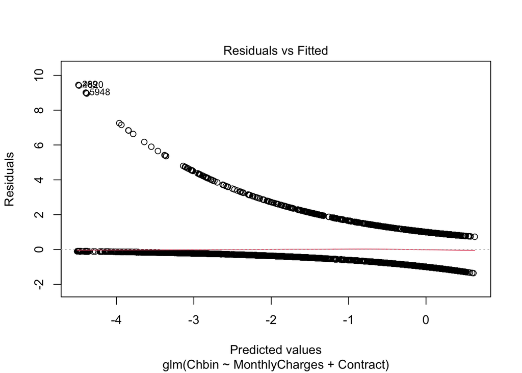

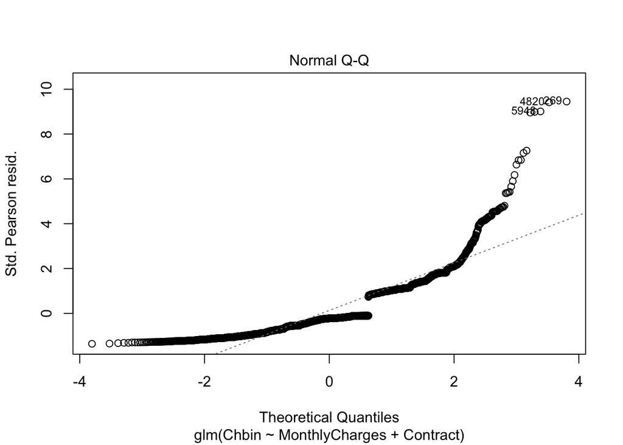

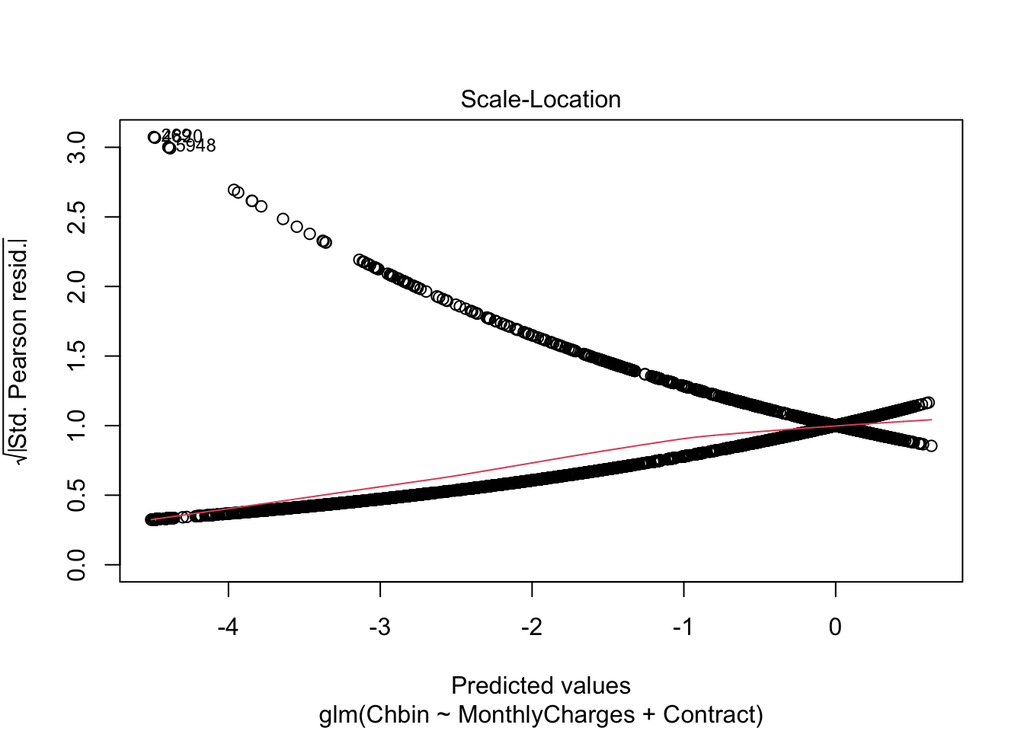

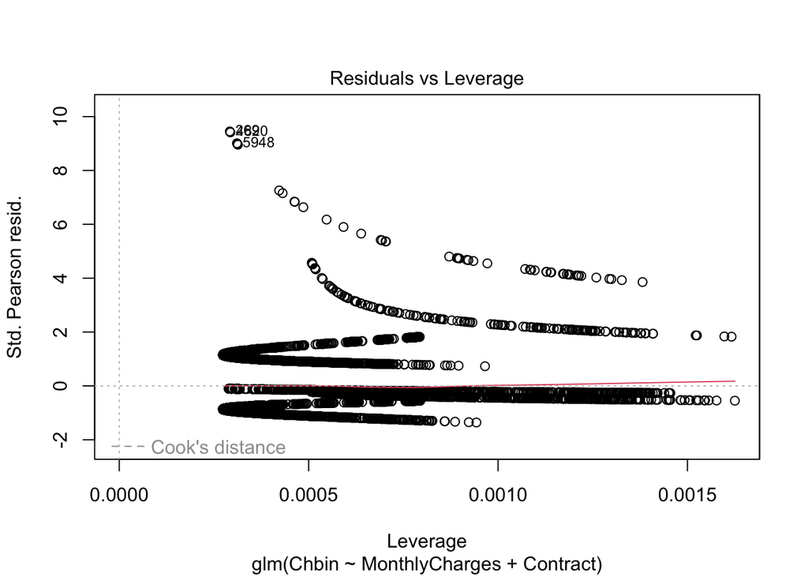

```r
plot(m9)
```

- Expand Now that we know contract length and churn rate is highly correlated, we can see which kinds of services combined with contract length have the most significant relationship. Do 2-year contracts with device protection have high significance with churn rates, or is it 1-year contracts with movie streaming?

```r
#Device protection & contract with churn
l1 <- lm(Chbin ~ DeviceProtection + Contract, data = telco)
summary(l1)
```

```
##
## Call:
## lm(formula = Chbin ~ DeviceProtection + Contract, data = telco)
##
## Residuals:
##      Min       1Q   Median       3Q      Max
## -0.47040 -0.44918 -0.05712  0.52960  0.96410
##
## Coefficients:
##                     Estimate Std. Error t value Pr(>|t|)
## (Intercept)          0.47040    0.00823  57.155   <2e-16 ***
## DeviceProtectionYes -0.02122    0.01268  -1.673   0.0944 .
## ContractOne year    -0.31647    0.01529 -20.696   <2e-16 ***
## ContractTwo year    -0.41328    0.01632 -25.327   <2e-16 ***
## ---
## Signif. codes:  0 '***' 0.001 '**' 0.01 '*' 0.05 '.' 0.1 ' ' 1
##
## Residual standard error: 0.4278 on 5513 degrees of freedom
##   (1526 observations deleted due to missingness)
## Multiple R-squared:  0.1571, Adjusted R-squared:  0.1567
## F-statistic: 342.6 on 3 and 5513 DF,  p-value: < 2.2e-16
```

Device protection lost its significance. Now we can combine all of the streaming services with contract length to try and see a difference.

```r
l2 <- lm(Chbin ~ DeviceProtection + PhoneService + InternetService + OnlineSecurity + OnlineBackup + StreamingTV + StreamingMovies + Contract, data =telco)
summary(l2)
```

```
##
## Call:
## lm(formula = Chbin ~ DeviceProtection + PhoneService + InternetService +
##     OnlineSecurity + OnlineBackup + StreamingTV + StreamingMovies +
##     Contract, data = telco)
##
## Residuals:
##      Min       1Q   Median       3Q      Max
## -0.60938 -0.35728 -0.08097  0.43207  1.10644
##
## Coefficients:
##                            Estimate Std. Error t value Pr(>|t|)
## (Intercept)                 0.44417    0.01793  24.768  < 2e-16 ***
## DeviceProtectionYes        -0.04145    0.01269  -3.266  0.00110 **
## PhoneServiceYes            -0.05000    0.01882  -2.657  0.00791 **
## InternetServiceFiber optic  0.15779    0.01332  11.847  < 2e-16 ***
## OnlineSecurityYes          -0.10272    0.01297  -7.918 2.89e-15 ***
## OnlineBackupYes            -0.07574    0.01197  -6.329 2.67e-10 ***
## StreamingTVYes              0.02780    0.01289   2.157  0.03102 *
## StreamingMoviesYes          0.02962    0.01290   2.296  0.02173 *
## ContractOne year           -0.25210    0.01579 -15.966  < 2e-16 ***
## ContractTwo year           -0.30850    0.01816 -16.987  < 2e-16 ***
## ---
## Signif. codes:  0 '***' 0.001 '**' 0.01 '*' 0.05 '.' 0.1 ' ' 1
##
## Residual standard error: 0.4152 on 5507 degrees of freedom
##   (1526 observations deleted due to missingness)
## Multiple R-squared:  0.2071, Adjusted R-squared:  0.2058
## F-statistic: 159.8 on 9 and 5507 DF,  p-value: < 2.2e-16
```

Tech Support and Multiple Lines weren’t included because I want to see later on if the availability of tech support by itself has an effect on churn rates, independent of all other variables. Multiple Lines wasn’t included because I don’t know what’s included in the variable Multiple Lines. Adding all of the services together with contract length was easier to see the relationships between each other.

I want to look a little further into internet service with contract length to try and see which individual service has the highest churn rate.

```r
table(telco$InternetService)
```

```
##
##         DSL Fiber optic          No
##        2421        3096        1526
```

```r
l3 <- lm(Chbin ~ InternetService + Contract, data = telco)
summary(l3)
```

```
##
## Call:
## lm(formula = Chbin ~ InternetService + Contract, data = telco)
##
## Residuals:
##      Min       1Q   Median       3Q      Max
## -0.51309 -0.34090 -0.06498  0.48691  1.05384
##
## Coefficients:
##                             Estimate Std. Error t value Pr(>|t|)
## (Intercept)                 0.340903   0.009297  36.666  < 2e-16 ***
## InternetServiceFiber optic  0.172188   0.010768  15.990  < 2e-16 ***
## InternetServiceNo          -0.061864   0.012928  -4.785 1.74e-06 ***
## ContractOne year           -0.275928   0.012122 -22.763  < 2e-16 ***
## ContractTwo year           -0.332880   0.011879 -28.022  < 2e-16 ***
## ---
## Signif. codes:  0 '***' 0.001 '**' 0.01 '*' 0.05 '.' 0.1 ' ' 1
##
## Residual standard error: 0.3912 on 7038 degrees of freedom
## Multiple R-squared:  0.2154, Adjusted R-squared:  0.2149
## F-statistic:   483 on 4 and 7038 DF,  p-value: < 2.2e-16
```

The third and final question we can answer is: Can we build a predictive model for churn?

The answer will be binary, either yes or no. This means we can use a logistic regression to interpret the results.  
Some good machine learning models that would’ve been ideal are random forest or a chi square test. But we can just create a linear predictive model by running a logistic regression model with some of the variables. We can add almost all of the variables we want to look (services) to see how the logistic model affects it. We can look at Gaussian and binomial to compare.

```r
#Can we build a predictive model for churn?

#Churn with Internet Service, TV Streaming, Movie Streaming, Online Service, Online Backup, Device Protection
m10 <- glm(Chbin ~ ISbin + STbin + SMbin + OSbin + OBbin + DPbin, family = c("binomial"), data = telco)
summary(m10)
```

```
##
## Call:
## glm(formula = Chbin ~ ISbin + STbin + SMbin + OSbin + OBbin +
##     DPbin, family = c("binomial"), data = telco)
##
## Deviance Residuals:
##     Min       1Q   Median       3Q      Max
## -1.2734  -0.9475  -0.5507   1.1241   2.2736
##
## Coefficients: (1 not defined because of singularities)
##             Estimate Std. Error z value Pr(>|z|)
## (Intercept)  0.03275    0.05250   0.624    0.533
## ISbin             NA         NA      NA       NA
## STbin        0.09597    0.06963   1.378    0.168
## SMbin        0.09406    0.06973   1.349    0.177
## OSbin       -1.26910    0.07331 -17.311   <2e-16 ***
## OBbin       -0.66898    0.06539 -10.231   <2e-16 ***
## DPbin       -0.60090    0.06798  -8.839   <2e-16 ***
## ---
## Signif. codes:  0 '***' 0.001 '**' 0.01 '*' 0.05 '.' 0.1 ' ' 1
##
## (Dispersion parameter for binomial family taken to be 1)
##
##     Null deviance: 6902.6  on 5516  degrees of freedom
## Residual deviance: 6220.0  on 5511  degrees of freedom
##   (1526 observations deleted due to missingness)
## AIC: 6232
##
## Number of Fisher Scoring iterations: 4
```

```r
#Exponetiate the coefficients
exp(coef(m10))
```

```
## (Intercept)       ISbin       STbin       SMbin       OSbin       OBbin
##   1.0332936          NA   1.1007248   1.0986244   0.2810853   0.5122296
##       DPbin
##   0.5483191
```

```r
sum(is.na(telco))
```

```
## [1] 24504
```

```r
telco_clean <- na.omit(telco)

#telco$predict_prob <- predict(m10, type = "response")
```

```r
#Telco clean
m11 <- glm(Chbin ~ ISbin + STbin + SMbin + OSbin + OBbin + DPbin, family = c("binomial"), data = telco_clean)
summary(m11)
```

```
##
## Call:
## glm(formula = Chbin ~ ISbin + STbin + SMbin + OSbin + OBbin +
##     DPbin, family = c("binomial"), data = telco_clean)
##
## Deviance Residuals:
##     Min       1Q   Median       3Q      Max
## -1.0564  -0.7180  -0.5423  -0.3663   2.3815
##
## Coefficients: (1 not defined because of singularities)
##             Estimate Std. Error z value Pr(>|z|)
## (Intercept)  -0.5471     0.1482  -3.691 0.000224 ***
## ISbin             NA         NA      NA       NA
## STbin         0.1075     0.1807   0.595 0.551924
## SMbin         0.1482     0.1807   0.820 0.411984
## OSbin        -1.0520     0.1759  -5.980 2.23e-09 ***
## OBbin        -0.6768     0.1628  -4.156 3.23e-05 ***
## DPbin        -0.4994     0.1717  -2.909 0.003627 **
## ---
## Signif. codes:  0 '***' 0.001 '**' 0.01 '*' 0.05 '.' 0.1 ' ' 1
##
## (Dispersion parameter for binomial family taken to be 1)
##
##     Null deviance: 1083.7  on 1067  degrees of freedom
## Residual deviance: 1002.0  on 1062  degrees of freedom
## AIC: 1014
##
## Number of Fisher Scoring iterations: 4
```

```r
#Predict churn probabilities
telco_clean$predicted_prob <- predict(m11, type = "response")

#This determines a cutoff threshold
telco_clean$predicted_class <- ifelse(telco_clean$predicted_prob > 0.5, 1, 0)
```

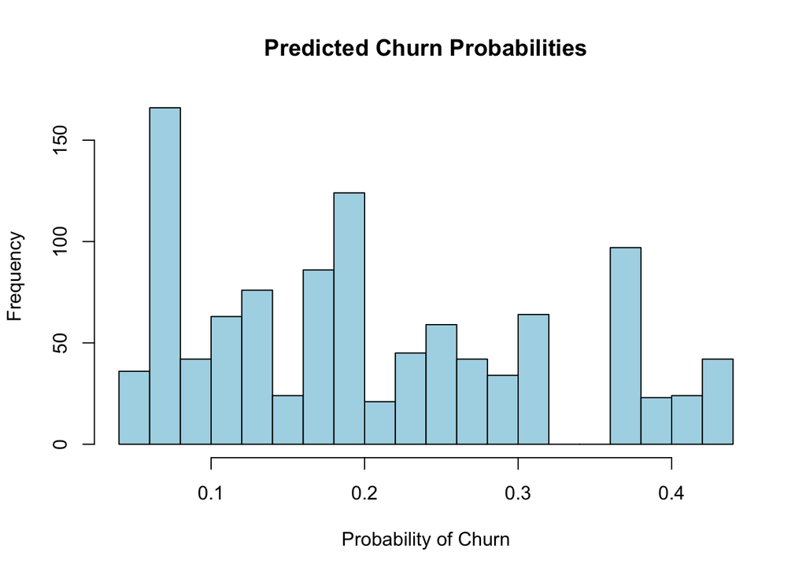

```r
hist(telco_clean$predicted_prob,
     breaks = 20,
     main = "Predicted Churn Probabilities",
     xlab = "Probability of Churn",
     col = "lightblue",
     border = "black")

abline(v = 0.5, col = "red", lwd = 2, lty = 2)  #vertical line at 0.5
```

We can also look at gaussian.

```r
m11 <- glm(Chbin ~ PSbin + ISbin + STbin + SMbin + OSbin + OBbin + DPbin + Paybin, family = c("gaussian"), data = telco)
summary(m11)
```

```
##
## Call:
## glm(formula = Chbin ~ PSbin + ISbin + STbin + SMbin + OSbin +
##     OBbin + DPbin + Paybin, family = c("gaussian"), data = telco)
##
## Deviance Residuals:
##      Min        1Q    Median        3Q       Max
## -0.38425  -0.25606  -0.14700  -0.01943   1.01340
##
## Coefficients: (2 not defined because of singularities)
##               Estimate Std. Error t value Pr(>|t|)
## (Intercept)  0.3220221  0.0383659   8.393  < 2e-16 ***
## PSbin        0.0325206  0.0344071   0.945  0.34476
## ISbin               NA         NA      NA       NA
## STbin        0.0003085  0.0250885   0.012  0.99019
## SMbin        0.0294000  0.0251731   1.168  0.24307
## OSbin       -0.1599158  0.0225311  -7.098 2.16e-12 ***
## OBbin       -0.0984820  0.0227550  -4.328 1.63e-05 ***
## DPbin       -0.0770231  0.0242296  -3.179  0.00152 **
## Paybin              NA         NA      NA       NA
## ---
## Signif. codes:  0 '***' 0.001 '**' 0.01 '*' 0.05 '.' 0.1 ' ' 1
##
## (Dispersion parameter for gaussian family taken to be 0.1469753)
##
##     Null deviance: 192.48  on 1211  degrees of freedom
## Residual deviance: 177.11  on 1205  degrees of freedom
##   (5831 observations deleted due to missingness)
## AIC: 1124.5
##
## Number of Fisher Scoring iterations: 2
```